# MovieLens Project Questions

### Project - MovieLens Data Analysis

The GroupLens Research Project is a research group in the Department of Computer Science and Engineering at the University of Minnesota. The data is widely used for collaborative filtering and other filtering solutions. However, we will be using this data to act as a means to demonstrate our skill in using Python to “play” with data.

### Datasets Information:

- Data.csv: It contains information of ratings given by the users to a particular movie. Columns: user id, movie id, rating, timestamp
- item.csv: File contains information related to the movies and its genre.
- Columns: movie id, movie title, release date, unknown, Action, Adventure, Animation, Children’s, Comedy, Crime, Documentary, Drama, Fantasy, Film-Noir, Horror, Musical, Mystery, Romance, Sci-Fi, Thriller, War, Western
- user.csv: It contains information of the users who have rated the movies. Columns: user id, age, gender, occupation, zip code

### Objective:

`To implement the techniques learnt as a part of the course.`

### Learning Outcomes:

- Exploratory Data Analysis
- Visualization using Python
- Pandas – groupby, merging

#### Domain

`Internet and Entertainment`

**Note that the project will need you to apply the concepts of groupby and merging extensively.**

#### 1. Import the necessary packages - 2.5 marks

```python
import pandas as pd
import numpy as np
import matplotlib
from matplotlib import pyplot as plt
import seaborn as sns
from scipy.stats import skew, norm, probplot, boxcox, f_oneway
```

#### 2. Read the 3 datasets into dataframes - 2.5 marks

```python
data = pd.read_csv('Data.csv')
item = pd.read_csv('item.csv')
user = pd.read_csv('user.csv')
```

```python
data.head()
```

|  | user id | movie id | rating | timestamp |
| --- | --- | --- | --- | --- |
| 0 | 196 | 242 | 3 | 881250949 |
| 1 | 186 | 302 | 3 | 891717742 |
| 2 | 22 | 377 | 1 | 878887116 |
| 3 | 244 | 51 | 2 | 880606923 |
| 4 | 166 | 346 | 1 | 886397596 |

```python
item.head()
```

[output not shown]

```python
user.head()
```

|  | user id | age | gender | occupation | zip code |
| --- | --- | --- | --- | --- | --- |
| 0 | 1 | 24 | M | technician | 85711 |
| 1 | 2 | 53 | F | other | 94043 |
| 2 | 3 | 23 | M | writer | 32067 |
| 3 | 4 | 24 | M | technician | 43537 |
| 4 | 5 | 33 | F | other | 15213 |

#### 3. Apply info, shape, describe, and find the number of missing values in the data - 5 marks

- Note that you will need to do it for all the three datasets seperately

```python
print(data.info)
print(data.shape)
data.describe()
```

```
<bound method DataFrame.info of        user id  movie id  rating  timestamp
0          196       242       3  881250949
1          186       302       3  891717742
2           22       377       1  878887116
3          244        51       2  880606923
4          166       346       1  886397596
...        ...       ...     ...        ...
99995      880       476       3  880175444
99996      716       204       5  879795543
99997      276      1090       1  874795795
99998       13       225       2  882399156
99999       12       203       3  879959583

[100000 rows x 4 columns]>
(100000, 4)
```

|  | user id | movie id | rating | timestamp |
| --- | --- | --- | --- | --- |
| count | 100000.00000 | 100000.000000 | 100000.000000 | 1.000000e+05 |
| mean | 462.48475 | 425.530130 | 3.529860 | 8.835289e+08 |
| std | 266.61442 | 330.798356 | 1.125674 | 5.343856e+06 |
| min | 1.00000 | 1.000000 | 1.000000 | 8.747247e+08 |
| 25% | 254.00000 | 175.000000 | 3.000000 | 8.794487e+08 |
| 50% | 447.00000 | 322.000000 | 4.000000 | 8.828269e+08 |
| 75% | 682.00000 | 631.000000 | 4.000000 | 8.882600e+08 |
| max | 943.00000 | 1682.000000 | 5.000000 | 8.932866e+08 |

```python
data.isnull().values.any()   # Any of the values in the dataframe is a missing value
```

```
False
```

```python
data.isnull().sum() # Total number of recognised missing values in the entire dataframe
```

```
user id      0
movie id     0
rating       0
timestamp    0
dtype: int64
```

```python
pd.DataFrame({'value' : data['user id'], 'Missing value?' : data['user id'].isnull()})
```

|  | value | Missing value? |
| --- | --- | --- |
| 0 | 196 | False |
| 1 | 186 | False |
| 2 | 22 | False |
| 3 | 244 | False |
| 4 | 166 | False |
| ... | ... | ... |
| 99995 | 880 | False |
| 99996 | 716 | False |
| 99997 | 276 | False |
| 99998 | 13 | False |
| 99999 | 12 | False |

100000 rows × 2 columns

```python
print(item.info)
print(item.shape)
item.describe()
```

```
<bound method DataFrame.info of       movie id                          movie title release date  unknown  \
0            1                           Toy Story   01-Jan-1995        0
1            2                           GoldenEye   01-Jan-1995        0
2            3                          Four Rooms   01-Jan-1995        0
3            4                          Get Shorty   01-Jan-1995        0
4            5                             Copycat   01-Jan-1995        0
...        ...                                  ...          ...      ...
1676      1678                          Mat' i syn   06-Feb-1998        0
1677      1679                           B. Monkey   06-Feb-1998        0
1678      1680                       Sliding Doors   01-Jan-1998        0
1679      1681                        You So Crazy   01-Jan-1994        0
1680      1682  Scream of Stone (Schrei aus Stein)   08-Mar-1996        0

      Action  Adventure  Animation  Childrens  Comedy  Crime  ...  Fantasy  \
0          0          0          1          1       1      0  ...        0
```

[output cut: 39 more lines]

|  | movie id | unknown | Action | Adventure | Animation | Childrens | Comedy | Crime | Documentary | Drama | Fantasy | Film-Noir | Horror | Musical | Mystery | Romance | Sci-Fi | Thriller | War | Western |
| --- | --- | --- | --- | --- | --- | --- | --- | --- | --- | --- | --- | --- | --- | --- | --- | --- | --- | --- | --- | --- |
| count | 1681.000000 | 1681.000000 | 1681.000000 | 1681.000000 | 1681.000000 | 1681.000000 | 1681.000000 | 1681.000000 | 1681.000000 | 1681.000000 | 1681.000000 | 1681.000000 | 1681.000000 | 1681.000000 | 1681.000000 | 1681.000000 | 1681.000000 | 1681.000000 | 1681.000000 | 1681.000000 |
| mean | 841.841761 | 0.000595 | 0.149316 | 0.080309 | 0.024985 | 0.072576 | 0.300416 | 0.064842 | 0.029744 | 0.431291 | 0.013087 | 0.014277 | 0.054729 | 0.033314 | 0.036288 | 0.146936 | 0.060083 | 0.149316 | 0.042237 | 0.016062 |
| std | 485.638077 | 0.024390 | 0.356506 | 0.271852 | 0.156126 | 0.259516 | 0.458576 | 0.246321 | 0.169931 | 0.495404 | 0.113683 | 0.118667 | 0.227519 | 0.179507 | 0.187061 | 0.354148 | 0.237712 | 0.356506 | 0.201189 | 0.125751 |
| min | 1.000000 | 0.000000 | 0.000000 | 0.000000 | 0.000000 | 0.000000 | 0.000000 | 0.000000 | 0.000000 | 0.000000 | 0.000000 | 0.000000 | 0.000000 | 0.000000 | 0.000000 | 0.000000 | 0.000000 | 0.000000 | 0.000000 | 0.000000 |
| 25% | 422.000000 | 0.000000 | 0.000000 | 0.000000 | 0.000000 | 0.000000 | 0.000000 | 0.000000 | 0.000000 | 0.000000 | 0.000000 | 0.000000 | 0.000000 | 0.000000 | 0.000000 | 0.000000 | 0.000000 | 0.000000 | 0.000000 | 0.000000 |
| 50% | 842.000000 | 0.000000 | 0.000000 | 0.000000 | 0.000000 | 0.000000 | 0.000000 | 0.000000 | 0.000000 | 0.000000 | 0.000000 | 0.000000 | 0.000000 | 0.000000 | 0.000000 | 0.000000 | 0.000000 | 0.000000 | 0.000000 | 0.000000 |
| 75% | 1262.000000 | 0.000000 | 0.000000 | 0.000000 | 0.000000 | 0.000000 | 1.000000 | 0.000000 | 0.000000 | 1.000000 | 0.000000 | 0.000000 | 0.000000 | 0.000000 | 0.000000 | 0.000000 | 0.000000 | 0.000000 | 0.000000 | 0.000000 |
| max | 1682.000000 | 1.000000 | 1.000000 | 1.000000 | 1.000000 | 1.000000 | 1.000000 | 1.000000 | 1.000000 | 1.000000 | 1.000000 | 1.000000 | 1.000000 | 1.000000 | 1.000000 | 1.000000 | 1.000000 | 1.000000 | 1.000000 | 1.000000 |

```python
item.isnull().values.any()   # Any of the values in the dataframe is a missing value
```

```
False
```

```python
item.isnull().sum()  # Total number of recognised missing values in the entire dataframe
```

```
movie id        0
movie title     0
release date    0
unknown         0
Action          0
Adventure       0
Animation       0
Childrens       0
Comedy          0
Crime           0
Documentary     0
Drama           0
Fantasy         0
Film-Noir       0
Horror          0
Musical         0
Mystery         0
Romance         0
Sci-Fi          0
Thriller        0
War             0
Western         0
dtype: int64
```

```python
print(user.info)
print(user.shape)
user.describe()
```

```
<bound method DataFrame.info of      user id  age gender     occupation zip code
0          1   24      M     technician    85711
1          2   53      F          other    94043
2          3   23      M         writer    32067
3          4   24      M     technician    43537
4          5   33      F          other    15213
..       ...  ...    ...            ...      ...
938      939   26      F        student    33319
939      940   32      M  administrator    02215
940      941   20      M        student    97229
941      942   48      F      librarian    78209
942      943   22      M        student    77841

[943 rows x 5 columns]>
(943, 5)
```

|  | user id | age |
| --- | --- | --- |
| count | 943.000000 | 943.000000 |
| mean | 472.000000 | 34.051962 |
| std | 272.364951 | 12.192740 |
| min | 1.000000 | 7.000000 |
| 25% | 236.500000 | 25.000000 |
| 50% | 472.000000 | 31.000000 |
| 75% | 707.500000 | 43.000000 |
| max | 943.000000 | 73.000000 |

```python
user.isnull().values.any()   # Any of the values in the dataframe is a missing value
```

```
False
```

```python
user.isnull().sum()  # Total number of recognised missing values in the entire dataframe
```

```
user id       0
age           0
gender        0
occupation    0
zip code      0
dtype: int64
```

#### 4. Find the number of movies per genre using the item data - 2.5 marks

```python
item.sum()# use sum on the default axis
```

```
movie id                                                  1415136
movie title     Toy Story GoldenEye Four Rooms Get Shorty Copy...
release date    01-Jan-199501-Jan-199501-Jan-199501-Jan-199501...
unknown                                                         1
Action                                                        251
Adventure                                                     135
Animation                                                      42
Childrens                                                     122
Comedy                                                        505
Crime                                                         109
Documentary                                                    50
Drama                                                         725
Fantasy                                                        22
Film-Noir                                                      24
Horror                                                         92
Musical                                                        56
Mystery                                                        61
Romance                                                       247
Sci-Fi                                                        101
Thriller                                                      251
War                                                            71
Western                                                        27
dtype: object
```

#### 5. Find the movies that have more than one genre - 5 marks

```python
item['movie genre']= item.iloc[:, 4:].sum(axis=1)   #sum total number of genre per movie
movies= item[['movie id', 'movie title','movie genre']]
movies = movies.loc[movies['movie genre'] >= 2] #find movies with more than one genre
movies
```

|  | movie id | movie title | movie genre |
| --- | --- | --- | --- |
| 0 | 1 | Toy Story | 3 |
| 1 | 2 | GoldenEye | 3 |
| 3 | 4 | Get Shorty | 3 |
| 4 | 5 | Copycat | 3 |
| 6 | 7 | Twelve Monkeys | 2 |
| ... | ... | ... | ... |
| 1667 | 1669 | MURDER and murder | 3 |
| 1668 | 1670 | Tainted | 2 |
| 1671 | 1673 | Mirage | 2 |
| 1677 | 1679 | B. Monkey | 2 |
| 1678 | 1680 | Sliding Doors | 2 |

849 rows × 3 columns

#### 6. Drop the movie where the genre is unknown - 2.5 marks

```python
item = item[item['unknown']!=1]
item
```

|  | movie id | movie title | release date | unknown | Action | Adventure | Animation | Childrens | Comedy | Crime | ... | Film-Noir | Horror | Musical | Mystery | Romance | Sci-Fi | Thriller | War | Western | movie genre |
| --- | --- | --- | --- | --- | --- | --- | --- | --- | --- | --- | --- | --- | --- | --- | --- | --- | --- | --- | --- | --- | --- |
| 0 | 1 | Toy Story | 01-Jan-1995 | 0 | 0 | 0 | 1 | 1 | 1 | 0 | ... | 0 | 0 | 0 | 0 | 0 | 0 | 0 | 0 | 0 | 3 |
| 1 | 2 | GoldenEye | 01-Jan-1995 | 0 | 1 | 1 | 0 | 0 | 0 | 0 | ... | 0 | 0 | 0 | 0 | 0 | 0 | 1 | 0 | 0 | 3 |
| 2 | 3 | Four Rooms | 01-Jan-1995 | 0 | 0 | 0 | 0 | 0 | 0 | 0 | ... | 0 | 0 | 0 | 0 | 0 | 0 | 1 | 0 | 0 | 1 |
| 3 | 4 | Get Shorty | 01-Jan-1995 | 0 | 1 | 0 | 0 | 0 | 1 | 0 | ... | 0 | 0 | 0 | 0 | 0 | 0 | 0 | 0 | 0 | 3 |
| 4 | 5 | Copycat | 01-Jan-1995 | 0 | 0 | 0 | 0 | 0 | 0 | 1 | ... | 0 | 0 | 0 | 0 | 0 | 0 | 1 | 0 | 0 | 3 |
| ... | ... | ... | ... | ... | ... | ... | ... | ... | ... | ... | ... | ... | ... | ... | ... | ... | ... | ... | ... | ... | ... |
| 1676 | 1678 | Mat' i syn | 06-Feb-1998 | 0 | 0 | 0 | 0 | 0 | 0 | 0 | ... | 0 | 0 | 0 | 0 | 0 | 0 | 0 | 0 | 0 | 1 |
| 1677 | 1679 | B. Monkey | 06-Feb-1998 | 0 | 0 | 0 | 0 | 0 | 0 | 0 | ... | 0 | 0 | 0 | 0 | 1 | 0 | 1 | 0 | 0 | 2 |
| 1678 | 1680 | Sliding Doors | 01-Jan-1998 | 0 | 0 | 0 | 0 | 0 | 0 | 0 | ... | 0 | 0 | 0 | 0 | 1 | 0 | 0 | 0 | 0 | 2 |
| 1679 | 1681 | You So Crazy | 01-Jan-1994 | 0 | 0 | 0 | 0 | 0 | 1 | 0 | ... | 0 | 0 | 0 | 0 | 0 | 0 | 0 | 0 | 0 | 1 |
| 1680 | 1682 | Scream of Stone (Schrei aus Stein) | 08-Mar-1996 | 0 | 0 | 0 | 0 | 0 | 0 | 0 | ... | 0 | 0 | 0 | 0 | 0 | 0 | 0 | 0 | 0 | 1 |

1680 rows × 23 columns

### 7. Univariate plots of columns: 'rating', 'Age', 'release year', 'Gender' and 'Occupation' - 10 marks

```python
# HINT: use distplot for age and countplot for gender,ratings,occupation, release year.
# HINT: Please refer to the below snippet to understand how to get to release year from release date. You can use str.split()
# as depicted below.
```

```python
a = 'my*cat*is*brown'
print(a.split('*')[3])

#similarly, the release year needs to be taken out from release date

#also you can simply slice existing string to get the desired data, if we want to take out the colour of the cat

print(a[10:])
print(a[-5:])
```

```
brown
brown
brown
```

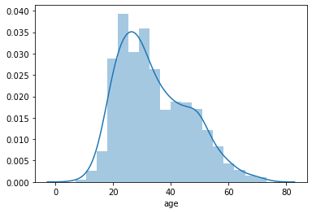

```python
#your answers here
sns.distplot(user['age'])
```

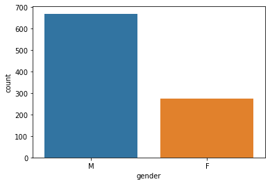

```python
sns.countplot(user['gender']);
```

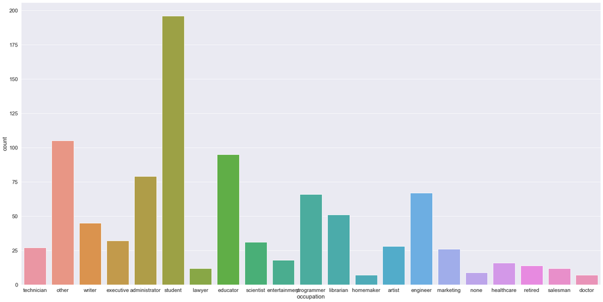

```python
plt.figure(figsize=(30,15))
sns.set(font_scale=1.4)
sns.countplot(user['occupation']);
```

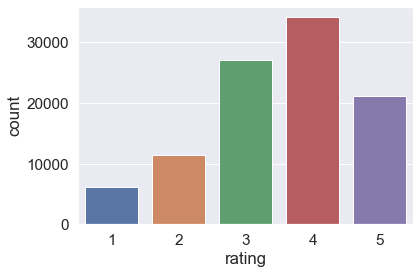

```python
sns.countplot(data['rating']);
```

```python
item["Year"] = pd.to_datetime(item["release date"]).dt.year
item
```

|  | movie id | movie title | release date | unknown | Action | Adventure | Animation | Childrens | Comedy | Crime | ... | Horror | Musical | Mystery | Romance | Sci-Fi | Thriller | War | Western | movie genre | Year |
| --- | --- | --- | --- | --- | --- | --- | --- | --- | --- | --- | --- | --- | --- | --- | --- | --- | --- | --- | --- | --- | --- |
| 0 | 1 | Toy Story | 01-Jan-1995 | 0 | 0 | 0 | 1 | 1 | 1 | 0 | ... | 0 | 0 | 0 | 0 | 0 | 0 | 0 | 0 | 3 | 1995 |
| 1 | 2 | GoldenEye | 01-Jan-1995 | 0 | 1 | 1 | 0 | 0 | 0 | 0 | ... | 0 | 0 | 0 | 0 | 0 | 1 | 0 | 0 | 3 | 1995 |
| 2 | 3 | Four Rooms | 01-Jan-1995 | 0 | 0 | 0 | 0 | 0 | 0 | 0 | ... | 0 | 0 | 0 | 0 | 0 | 1 | 0 | 0 | 1 | 1995 |
| 3 | 4 | Get Shorty | 01-Jan-1995 | 0 | 1 | 0 | 0 | 0 | 1 | 0 | ... | 0 | 0 | 0 | 0 | 0 | 0 | 0 | 0 | 3 | 1995 |
| 4 | 5 | Copycat | 01-Jan-1995 | 0 | 0 | 0 | 0 | 0 | 0 | 1 | ... | 0 | 0 | 0 | 0 | 0 | 1 | 0 | 0 | 3 | 1995 |
| ... | ... | ... | ... | ... | ... | ... | ... | ... | ... | ... | ... | ... | ... | ... | ... | ... | ... | ... | ... | ... | ... |
| 1676 | 1678 | Mat' i syn | 06-Feb-1998 | 0 | 0 | 0 | 0 | 0 | 0 | 0 | ... | 0 | 0 | 0 | 0 | 0 | 0 | 0 | 0 | 1 | 1998 |
| 1677 | 1679 | B. Monkey | 06-Feb-1998 | 0 | 0 | 0 | 0 | 0 | 0 | 0 | ... | 0 | 0 | 0 | 1 | 0 | 1 | 0 | 0 | 2 | 1998 |
| 1678 | 1680 | Sliding Doors | 01-Jan-1998 | 0 | 0 | 0 | 0 | 0 | 0 | 0 | ... | 0 | 0 | 0 | 1 | 0 | 0 | 0 | 0 | 2 | 1998 |
| 1679 | 1681 | You So Crazy | 01-Jan-1994 | 0 | 0 | 0 | 0 | 0 | 1 | 0 | ... | 0 | 0 | 0 | 0 | 0 | 0 | 0 | 0 | 1 | 1994 |
| 1680 | 1682 | Scream of Stone (Schrei aus Stein) | 08-Mar-1996 | 0 | 0 | 0 | 0 | 0 | 0 | 0 | ... | 0 | 0 | 0 | 0 | 0 | 0 | 0 | 0 | 1 | 1996 |

1680 rows × 24 columns

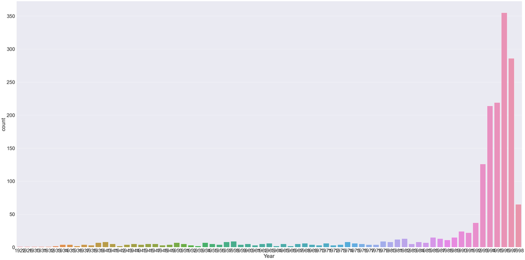

```python
plt.figure(figsize=(60,30))
sns.set(font_scale=3)
sns.countplot(item['Year']);
```

### 8. Visualize how popularity of genres has changed over the years - 10 marks

Note that you need to use the number of releases in a year as a parameter of popularity of a genre

Hint

1: you need to reach to a data frame where the release year is the index and the genre is the column names (one cell shows the number of release in a year in one genre) or vice versa. Once that is achieved, you can either use multiple bivariate plots or can use the heatmap to visualise all the changes over the years in one go.

Hint 2: Use groupby on the relevant column and use sum() on the same to find out the nuumber of releases in a year/genre.

```python
#drop movie genre, unkown and movie id from dataframe
item_drop=item.drop(columns=['movie genre','unknown','movie id'])

#group data frame by Year
grouped_data = item_drop.groupby('Year')

#sum reviews in each genre
all_movies_all_times=grouped_data.sum()

#jsut for clearer reading visibility trasnpose dat frame to have years as columns and genres in rows
all_movies_all_times_t= all_movies_all_times.transpose()
all_movies_all_times_t
```

| Year | 1922 | 1926 | 1930 | 1931 | 1932 | 1933 | 1934 | 1935 | 1936 | 1937 | ... | 1989 | 1990 | 1991 | 1992 | 1993 | 1994 | 1995 | 1996 | 1997 | 1998 |
| --- | --- | --- | --- | --- | --- | --- | --- | --- | --- | --- | --- | --- | --- | --- | --- | --- | --- | --- | --- | --- | --- |
| Action | 0 | 0 | 0 | 0 | 0 | 0 | 0 | 0 | 0 | 0 | ... | 6 | 7 | 2 | 8 | 20 | 30 | 40 | 44 | 46 | 12 |
| Adventure | 0 | 0 | 0 | 0 | 0 | 0 | 0 | 0 | 0 | 0 | ... | 4 | 1 | 1 | 1 | 9 | 13 | 22 | 24 | 20 | 3 |
| Animation | 0 | 0 | 0 | 0 | 0 | 0 | 0 | 0 | 0 | 1 | ... | 0 | 0 | 1 | 2 | 1 | 4 | 6 | 9 | 3 | 0 |
| Childrens | 0 | 0 | 0 | 0 | 0 | 0 | 0 | 0 | 0 | 1 | ... | 0 | 1 | 1 | 1 | 6 | 15 | 21 | 21 | 22 | 1 |
| Comedy | 0 | 0 | 0 | 0 | 0 | 1 | 2 | 2 | 1 | 2 | ... | 3 | 6 | 6 | 12 | 39 | 82 | 63 | 108 | 87 | 13 |
| Crime | 0 | 0 | 0 | 1 | 0 | 0 | 0 | 0 | 0 | 0 | ... | 1 | 3 | 0 | 5 | 7 | 8 | 11 | 21 | 30 | 7 |
| Documentary | 0 | 0 | 0 | 0 | 0 | 0 | 0 | 0 | 0 | 0 | ... | 0 | 2 | 1 | 0 | 4 | 9 | 5 | 18 | 6 | 3 |
| Drama | 0 | 1 | 1 | 0 | 0 | 0 | 1 | 0 | 1 | 1 | ... | 8 | 12 | 11 | 14 | 64 | 97 | 89 | 170 | 113 | 33 |
| Fantasy | 0 | 0 | 0 | 0 | 0 | 0 | 0 | 0 | 0 | 0 | ... | 0 | 0 | 1 | 0 | 0 | 3 | 3 | 6 | 4 | 1 |
| Film-Noir | 0 | 0 | 0 | 1 | 0 | 0 | 0 | 0 | 0 | 0 | ... | 0 | 1 | 0 | 0 | 1 | 0 | 1 | 1 | 2 | 2 |
| Horror | 1 | 0 | 0 | 0 | 0 | 0 | 0 | 1 | 0 | 0 | ... | 0 | 1 | 1 | 6 | 5 | 8 | 14 | 11 | 8 | 4 |
| Musical | 0 | 0 | 0 | 0 | 0 | 0 | 1 | 1 | 0 | 3 | ... | 0 | 0 | 2 | 1 | 2 | 2 | 3 | 9 | 5 | 1 |
| Mystery | 0 | 0 | 0 | 0 | 0 | 0 | 1 | 0 | 0 | 0 | ... | 0 | 0 | 0 | 1 | 6 | 2 | 5 | 6 | 18 | 3 |
| Romance | 0 | 0 | 0 | 0 | 1 | 1 | 1 | 1 | 0 | 2 | ... | 1 | 4 | 0 | 7 | 16 | 35 | 37 | 38 | 51 | 11 |
| Sci-Fi | 0 | 0 | 0 | 0 | 0 | 0 | 0 | 0 | 0 | 0 | ... | 2 | 0 | 4 | 3 | 8 | 7 | 15 | 15 | 13 | 5 |
| Thriller | 0 | 0 | 0 | 1 | 0 | 0 | 0 | 1 | 0 | 0 | ... | 2 | 4 | 3 | 5 | 17 | 25 | 39 | 47 | 54 | 18 |
| War | 0 | 0 | 0 | 0 | 1 | 1 | 0 | 0 | 0 | 0 | ... | 2 | 0 | 1 | 2 | 4 | 7 | 5 | 9 | 14 | 0 |
| Western | 0 | 0 | 0 | 0 | 0 | 0 | 0 | 0 | 0 | 0 | ... | 0 | 2 | 0 | 1 | 2 | 6 | 2 | 2 | 0 | 0 |

18 rows × 71 columns

### Heatflow map

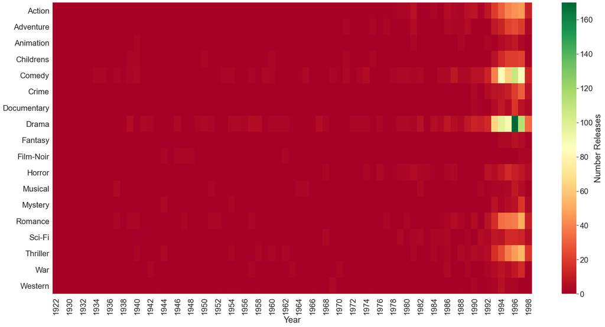

```python
plt.figure(figsize=(30,15))
sns.set(font_scale=2)
ax = sns.heatmap(all_movies_all_times_t, cmap="RdYlGn", cbar_kws={'label': 'Number Releases'},annot=False)
```

Historically Drama and Comedy seem to be the most popular genres, with an explosion of number of releases in the 90's. In particular, record for Drama (170 realeses in 1996 alone!). Although not particualry popular pre-80's, Romance and Thriller and Action genres have seen a surge in movie releases in the 90's.

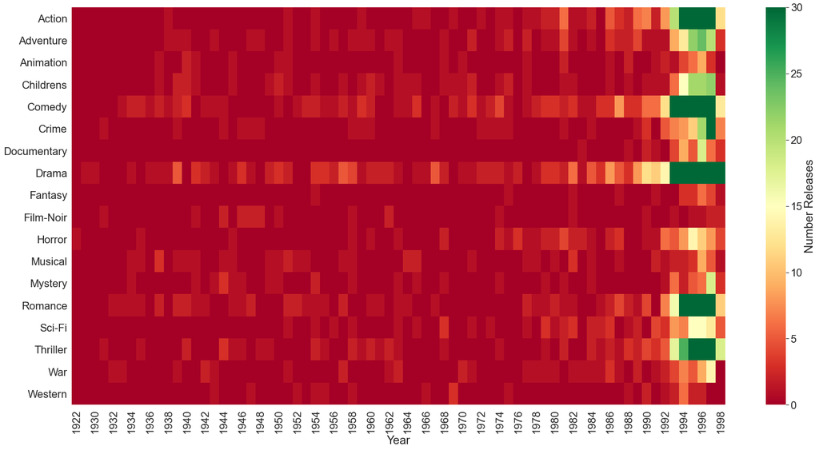

```python
plt.figure(figsize=(30,15))
sns.set(font_scale=2)
ax = sns.heatmap(all_movies_all_times_t, cmap="RdYlGn", cbar_kws={'label': 'Number Releases'},vmin=0, vmax=30, annot=False)
```

We can increase visibility of releases between 1922 and 1990 by reducing the max range of the colorbar to 30. We can see that comedy and drama were historically the most popular genres that accounted for most releases in that time frame. The 90's surge in Drama, Comedy is followed by a noticeable increse in Action, Romance and Thriller. Latly, Adventure and Children have also incresead at smaller levels in the 90's. It would be intersting to see the evolution of the release in genres post 2000's.

### 9. Find the top 25 movies according to average ratings such that each movie has number of ratings more than 100 - 10 marks

Hint :

1. First find the movies that have more than 100 ratings(use merge, groupby and count). Extract the movie id in a list.
2. Find the average rating of all the movies and sort them in the descending order. You will have to use the .merge() function to reach to a data set through which you can get the ids and the average rating.
3. Use isin(list obtained from 1) to filter out the movies which have more than 100 ratings.

Note: This question will need you to research about groupby and apply your findings. You can find more on groupby on https://realpython.com/pandas-groupby/.

```python
movie_ratings = pd.merge(data,item)
movie_ratings
```

|  | user id | movie id | rating | timestamp | movie title | release date | unknown | Action | Adventure | Animation | ... | Horror | Musical | Mystery | Romance | Sci-Fi | Thriller | War | Western | movie genre | Year |
| --- | --- | --- | --- | --- | --- | --- | --- | --- | --- | --- | --- | --- | --- | --- | --- | --- | --- | --- | --- | --- | --- |
| 0 | 196 | 242 | 3 | 881250949 | Kolya | 24-Jan-1997 | 0 | 0 | 0 | 0 | ... | 0 | 0 | 0 | 0 | 0 | 0 | 0 | 0 | 1 | 1997 |
| 1 | 63 | 242 | 3 | 875747190 | Kolya | 24-Jan-1997 | 0 | 0 | 0 | 0 | ... | 0 | 0 | 0 | 0 | 0 | 0 | 0 | 0 | 1 | 1997 |
| 2 | 226 | 242 | 5 | 883888671 | Kolya | 24-Jan-1997 | 0 | 0 | 0 | 0 | ... | 0 | 0 | 0 | 0 | 0 | 0 | 0 | 0 | 1 | 1997 |
| 3 | 154 | 242 | 3 | 879138235 | Kolya | 24-Jan-1997 | 0 | 0 | 0 | 0 | ... | 0 | 0 | 0 | 0 | 0 | 0 | 0 | 0 | 1 | 1997 |
| 4 | 306 | 242 | 5 | 876503793 | Kolya | 24-Jan-1997 | 0 | 0 | 0 | 0 | ... | 0 | 0 | 0 | 0 | 0 | 0 | 0 | 0 | 1 | 1997 |
| ... | ... | ... | ... | ... | ... | ... | ... | ... | ... | ... | ... | ... | ... | ... | ... | ... | ... | ... | ... | ... | ... |
| 99985 | 840 | 1674 | 4 | 891211682 | Mamma Roma | 01-Jan-1962 | 0 | 0 | 0 | 0 | ... | 0 | 0 | 0 | 0 | 0 | 0 | 0 | 0 | 1 | 1962 |
| 99986 | 655 | 1640 | 3 | 888474646 | Eighth Day, The | 01-Nov-1996 | 0 | 0 | 0 | 0 | ... | 0 | 0 | 0 | 0 | 0 | 0 | 0 | 0 | 1 | 1996 |
| 99987 | 655 | 1637 | 3 | 888984255 | Girls Town | 23-Aug-1996 | 0 | 0 | 0 | 0 | ... | 0 | 0 | 0 | 0 | 0 | 0 | 0 | 0 | 1 | 1996 |
| 99988 | 655 | 1630 | 3 | 887428735 | Silence of the Palace, The (Saimt el Qusur) | 02-Feb-1996 | 0 | 0 | 0 | 0 | ... | 0 | 0 | 0 | 0 | 0 | 0 | 0 | 0 | 1 | 1996 |
| 99989 | 655 | 1641 | 3 | 887427810 | Dadetown | 18-Sep-1996 | 0 | 0 | 0 | 0 | ... | 0 | 0 | 0 | 0 | 0 | 0 | 0 | 0 | 1 | 1996 |

99990 rows × 27 columns

```python
#Find movies wiht more than 100 ratings
hundered_most_rated=movie_ratings[movie_ratings['movie id'].isin(movie_ratings['movie id'].value_counts()[movie_ratings['movie id'].value_counts()>100].index)]
hundered_most_rated
```

|  | user id | movie id | rating | timestamp | movie title | release date | unknown | Action | Adventure | Animation | ... | Horror | Musical | Mystery | Romance | Sci-Fi | Thriller | War | Western | movie genre | Year |
| --- | --- | --- | --- | --- | --- | --- | --- | --- | --- | --- | --- | --- | --- | --- | --- | --- | --- | --- | --- | --- | --- |
| 0 | 196 | 242 | 3 | 881250949 | Kolya | 24-Jan-1997 | 0 | 0 | 0 | 0 | ... | 0 | 0 | 0 | 0 | 0 | 0 | 0 | 0 | 1 | 1997 |
| 1 | 63 | 242 | 3 | 875747190 | Kolya | 24-Jan-1997 | 0 | 0 | 0 | 0 | ... | 0 | 0 | 0 | 0 | 0 | 0 | 0 | 0 | 1 | 1997 |
| 2 | 226 | 242 | 5 | 883888671 | Kolya | 24-Jan-1997 | 0 | 0 | 0 | 0 | ... | 0 | 0 | 0 | 0 | 0 | 0 | 0 | 0 | 1 | 1997 |
| 3 | 154 | 242 | 3 | 879138235 | Kolya | 24-Jan-1997 | 0 | 0 | 0 | 0 | ... | 0 | 0 | 0 | 0 | 0 | 0 | 0 | 0 | 1 | 1997 |
| 4 | 306 | 242 | 5 | 876503793 | Kolya | 24-Jan-1997 | 0 | 0 | 0 | 0 | ... | 0 | 0 | 0 | 0 | 0 | 0 | 0 | 0 | 1 | 1997 |
| ... | ... | ... | ... | ... | ... | ... | ... | ... | ... | ... | ... | ... | ... | ... | ... | ... | ... | ... | ... | ... | ... |
| 93430 | 820 | 358 | 1 | 887954972 | Spawn | 01-Aug-1997 | 0 | 1 | 1 | 0 | ... | 0 | 0 | 0 | 0 | 1 | 1 | 0 | 0 | 4 | 1997 |
| 93431 | 397 | 358 | 2 | 882838937 | Spawn | 01-Aug-1997 | 0 | 1 | 1 | 0 | ... | 0 | 0 | 0 | 0 | 1 | 1 | 0 | 0 | 4 | 1997 |
| 93432 | 827 | 358 | 2 | 882808622 | Spawn | 01-Aug-1997 | 0 | 1 | 1 | 0 | ... | 0 | 0 | 0 | 0 | 1 | 1 | 0 | 0 | 4 | 1997 |
| 93433 | 757 | 358 | 3 | 888443570 | Spawn | 01-Aug-1997 | 0 | 1 | 1 | 0 | ... | 0 | 0 | 0 | 0 | 1 | 1 | 0 | 0 | 4 | 1997 |
| 93434 | 574 | 358 | 2 | 891279520 | Spawn | 01-Aug-1997 | 0 | 1 | 1 | 0 | ... | 0 | 0 | 0 | 0 | 1 | 1 | 0 | 0 | 4 | 1997 |

64419 rows × 27 columns

```python
#groupby movie title and create mean values
movie_stats = hundered_most_rated.groupby('movie title').agg({'rating': [np.mean]})
movie_stats
```

| movie title | rating mean |
| --- | --- |
| 101 Dalmatians | 2.908257 |
| 12 Angry Men | 4.344000 |
| 2001: A Space Odyssey | 3.969112 |
| Absolute Power | 3.370079 |
| Abyss, The | 3.589404 |
| ... | ... |
| Willy Wonka and the Chocolate Factory | 3.631902 |
| Wizard of Oz, The | 4.077236 |
| Wrong Trousers, The | 4.466102 |
| Young Frankenstein | 3.945000 |
| Young Guns | 3.207921 |

333 rows × 1 columns

```python
#extract 25 highest rated movies for movies with more than 100 reviews
highest_rated=movie_stats.sort_values([('rating', 'mean')], ascending=False)[:25]
highest_rated #Top 25 movies based on rating
```

| movie title | rating mean |
| --- | --- |
| Close Shave, A | 4.491071 |
| Schindler's List | 4.466443 |
| Wrong Trousers, The | 4.466102 |
| Casablanca | 4.456790 |
| Shawshank Redemption, The | 4.445230 |
| Rear Window | 4.387560 |
| Usual Suspects, The | 4.385768 |
| Star Wars | 4.358491 |
| 12 Angry Men | 4.344000 |
| Citizen Kane | 4.292929 |
| To Kill a Mockingbird | 4.292237 |
| One Flew Over the Cuckoo's Nest | 4.291667 |
| Silence of the Lambs, The | 4.289744 |
| North by Northwest | 4.284916 |
| Godfather, The | 4.283293 |
| Secrets & Lies | 4.265432 |
| Good Will Hunting | 4.262626 |
| Manchurian Candidate, The | 4.259542 |
| Dr. Strangelove or: How I Learned to Stop Worrying and Love the Bomb | 4.252577 |
| Raiders of the Lost Ark | 4.252381 |
| Vertigo | 4.251397 |
| Titanic | 4.245714 |
| Lawrence of Arabia | 4.231214 |
| Maltese Falcon, The | 4.210145 |
| Empire Strikes Back, The | 4.204360 |

```python
#most rated movies in number of reviews
most_rated = movie_ratings.groupby('movie title').size().sort_values(ascending=False)[:25]
most_rated
```

```
movie title
Star Wars                              583
Contact                                509
Fargo                                  508
Return of the Jedi                     507
Liar Liar                              485
English Patient, The                   481
Scream                                 478
Toy Story                              452
Air Force One                          431
Independence Day (ID4)                 429
Raiders of the Lost Ark                420
Godfather, The                         413
Pulp Fiction                           394
Twelve Monkeys                         392
Silence of the Lambs, The              390
Jerry Maguire                          384
Chasing Amy                            379
Rock, The                              378
Empire Strikes Back, The               367
Star Trek: First Contact               365
Titanic                                350
Back to the Future                     350
Mission: Impossible                    344
Fugitive, The                          336
Indiana Jones and the Last Crusade     331
dtype: int64
```

### 10. See gender distribution across different genres check for the validity of the below statements - 10 marks

- Men watch more drama than women
- Women watch more Sci-Fi than men
- Men watch more Romance than women
1. There is no need to conduct statistical tests around this. Just compare the percentages and comment on the validity of the above statements.
2. you might want ot use the .sum(), .div() function here.
3. Use number of ratings to validate the numbers. For example, if out of 4000 ratings received by women, 3000 are for drama, we will assume that 75% of the women watch drama.

#### Conclusion:

Men watch more drama than women: False  
Women watch more Sci-Fi than men: False  
Men watch more Romance than women: False

### Data clean up

```python
#merge two dataframes
users_ratings= pd.merge(user,movie_ratings)
users_ratings
```

|  | user id | age | gender | occupation | zip code | movie id | rating | timestamp | movie title | release date | ... | Horror | Musical | Mystery | Romance | Sci-Fi | Thriller | War | Western | movie genre | Year |
| --- | --- | --- | --- | --- | --- | --- | --- | --- | --- | --- | --- | --- | --- | --- | --- | --- | --- | --- | --- | --- | --- |
| 0 | 1 | 24 | M | technician | 85711 | 242 | 5 | 889751633 | Kolya | 24-Jan-1997 | ... | 0 | 0 | 0 | 0 | 0 | 0 | 0 | 0 | 1 | 1997 |
| 1 | 1 | 24 | M | technician | 85711 | 51 | 4 | 878543275 | Legends of the Fall | 01-Jan-1994 | ... | 0 | 0 | 0 | 1 | 0 | 0 | 1 | 1 | 4 | 1994 |
| 2 | 1 | 24 | M | technician | 85711 | 265 | 4 | 878542441 | Hunt for Red October, The | 01-Jan-1990 | ... | 0 | 0 | 0 | 0 | 0 | 1 | 0 | 0 | 2 | 1990 |
| 3 | 1 | 24 | M | technician | 85711 | 86 | 5 | 878543541 | Remains of the Day, The | 01-Jan-1993 | ... | 0 | 0 | 0 | 0 | 0 | 0 | 0 | 0 | 1 | 1993 |
| 4 | 1 | 24 | M | technician | 85711 | 257 | 4 | 874965954 | Men in Black | 04-Jul-1997 | ... | 0 | 0 | 0 | 0 | 1 | 0 | 0 | 0 | 4 | 1997 |
| ... | ... | ... | ... | ... | ... | ... | ... | ... | ... | ... | ... | ... | ... | ... | ... | ... | ... | ... | ... | ... | ... |
| 99985 | 943 | 22 | M | student | 77841 | 1188 | 3 | 888640250 | Young Guns II | 01-Jan-1990 | ... | 0 | 0 | 0 | 0 | 0 | 0 | 0 | 1 | 3 | 1990 |
| 99986 | 943 | 22 | M | student | 77841 | 415 | 1 | 888640027 | Apple Dumpling Gang, The | 01-Jan-1975 | ... | 0 | 0 | 0 | 0 | 0 | 0 | 0 | 1 | 3 | 1975 |
| 99987 | 943 | 22 | M | student | 77841 | 373 | 3 | 888640275 | Judge Dredd | 01-Jan-1995 | ... | 0 | 0 | 0 | 0 | 1 | 0 | 0 | 0 | 3 | 1995 |
| 99988 | 943 | 22 | M | student | 77841 | 541 | 4 | 888639954 | Mortal Kombat | 01-Jan-1995 | ... | 0 | 0 | 0 | 0 | 0 | 0 | 0 | 0 | 2 | 1995 |
| 99989 | 943 | 22 | M | student | 77841 | 1330 | 3 | 888692465 | An Unforgettable Summer | 01-Jan-1994 | ... | 0 | 0 | 0 | 0 | 0 | 0 | 0 | 0 | 1 | 1994 |

99990 rows × 31 columns

```python
#drop several columns
gender_ratings= users_ratings.drop(['user id', 'movie id','release date','movie title', 'timestamp','unknown','movie genre','Year','age','occupation','zip code'], axis=1)
```

## Method 1

```python
#For quick investigation I use .mean() . For clearer readthorugh I multiply results by 100, round to one decimal and transposed the datafarame
gender_preference=gender_ratings.groupby('gender').mean()*100
gender_preference.round(decimals=1).T
```

| gender | F | M |
| --- | --- | --- |
| rating | 353.2 | 352.9 |
| Action | 21.1 | 27.1 |
| Adventure | 12.2 | 14.3 |
| Animation | 3.9 | 3.5 |
| Childrens | 8.7 | 6.7 |
| Comedy | 31.3 | 29.3 |
| Crime | 7.0 | 8.4 |
| Documentary | 0.7 | 0.8 |
| Drama | 42.8 | 38.9 |
| Fantasy | 1.4 | 1.3 |
| Film-Noir | 1.5 | 1.8 |
| Horror | 4.7 | 5.5 |
| Musical | 5.6 | 4.7 |
| Mystery | 5.1 | 5.3 |
| Romance | 22.8 | 18.3 |
| Sci-Fi | 10.2 | 13.6 |
| Thriller | 19.8 | 22.6 |
| War | 8.5 | 9.7 |
| Western | 1.4 | 2.0 |

## Method 2

Conclusions:  
Men watch more drama than women. False  
Women watch more Sci-Fi than men. False  
Men watch more Romance than women. False

```python
#I group the dataframe by gender and apply .sum() to get sum of reviews by genre
gender_ratings1 = gender_ratings.groupby(['gender']).sum()
```

```python
gender_ratings1
```

| gender | rating | Action | Adventure | Animation | Childrens | Comedy | Crime | Documentary | Drama | Fantasy | Film-Noir | Horror | Musical | Mystery | Romance | Sci-Fi | Thriller | War | Western |
| --- | --- | --- | --- | --- | --- | --- | --- | --- | --- | --- | --- | --- | --- | --- | --- | --- | --- | --- | --- |
| F | 90894 | 5442 | 3141 | 995 | 2232 | 8068 | 1794 | 187 | 11008 | 363 | 385 | 1197 | 1442 | 1314 | 5858 | 2629 | 5086 | 2189 | 371 |
| M | 262060 | 20147 | 10612 | 2610 | 4950 | 21764 | 6261 | 571 | 28887 | 989 | 1348 | 4120 | 3512 | 3931 | 13603 | 10101 | 16786 | 7209 | 1483 |

```python
gender_ratings1.drop(['rating'],axis=1, inplace=True)
```

```python
gender_ratings1
```

| gender | Action | Adventure | Animation | Childrens | Comedy | Crime | Documentary | Drama | Fantasy | Film-Noir | Horror | Musical | Mystery | Romance | Sci-Fi | Thriller | War | Western |
| --- | --- | --- | --- | --- | --- | --- | --- | --- | --- | --- | --- | --- | --- | --- | --- | --- | --- | --- |
| F | 5442 | 3141 | 995 | 2232 | 8068 | 1794 | 187 | 11008 | 363 | 385 | 1197 | 1442 | 1314 | 5858 | 2629 | 5086 | 2189 | 371 |
| M | 20147 | 10612 | 2610 | 4950 | 21764 | 6261 | 571 | 28887 | 989 | 1348 | 4120 | 3512 | 3931 | 13603 | 10101 | 16786 | 7209 | 1483 |

```python
#the total number of ratings in gender_Ratings1 (352,954) is larger than in the user ratings data frame (99,990). We fix that by concatenating the total ratings column of the user_ratings dataframe to the gender_ratings1 dataframe. The
size_ratings= users_ratings.groupby('gender').count()
```

```python
size_ratings=size_ratings[['rating']]
size_ratings_total=size_ratings.rename(columns={"rating": "Total"})
```

```python
size_ratings_total
```

| gender | Total |
| --- | --- |
| F | 25738 |
| M | 74252 |

```python
#concatenate the two dataframes
comparative_dataset= pd.concat([size_ratings_total,gender_ratings1],axis=1,sort=False)
```

```python
comparative_dataset
```

| gender | Total | Action | Adventure | Animation | Childrens | Comedy | Crime | Documentary | Drama | Fantasy | Film-Noir | Horror | Musical | Mystery | Romance | Sci-Fi | Thriller | War | Western |
| --- | --- | --- | --- | --- | --- | --- | --- | --- | --- | --- | --- | --- | --- | --- | --- | --- | --- | --- | --- |
| F | 25738 | 5442 | 3141 | 995 | 2232 | 8068 | 1794 | 187 | 11008 | 363 | 385 | 1197 | 1442 | 1314 | 5858 | 2629 | 5086 | 2189 | 371 |
| M | 74252 | 20147 | 10612 | 2610 | 4950 | 21764 | 6261 | 571 | 28887 | 989 | 1348 | 4120 | 3512 | 3931 | 13603 | 10101 | 16786 | 7209 | 1483 |

```python
#Calculate percentages of ratings relative to total ratings per gender.
percentages= comparative_dataset.iloc[:,1:].div(comparative_dataset.Total, axis=0)*100
precentage_transposed= percentages.T
```

```python
precentage_transposed
```

| gender | F | M |
| --- | --- | --- |
| Action | 21.143834 | 27.133276 |
| Adventure | 12.203745 | 14.291871 |
| Animation | 3.865879 | 3.515057 |
| Childrens | 8.672002 | 6.666487 |
| Comedy | 31.346647 | 29.310995 |
| Crime | 6.970239 | 8.432096 |
| Documentary | 0.726552 | 0.769003 |
| Drama | 42.769446 | 38.904003 |
| Fantasy | 1.410366 | 1.331951 |
| Film-Noir | 1.495843 | 1.815439 |
| Horror | 4.650711 | 5.548672 |
| Musical | 5.602611 | 4.729839 |
| Mystery | 5.105292 | 5.294133 |
| Romance | 22.760121 | 18.320045 |
| Sci-Fi | 10.214469 | 13.603674 |
| Thriller | 19.760665 | 22.606798 |
| War | 8.504934 | 9.708829 |
| Western | 1.441448 | 1.997253 |

The question was adressed to the genres drama, romance and sci-fi.

```python
selected_genres = percentages[['Drama', 'Romance','Sci-Fi']]
selected_genres
```

| gender | Drama | Romance | Sci-Fi |
| --- | --- | --- | --- |
| F | 42.769446 | 22.760121 | 10.214469 |
| M | 38.904003 | 18.320045 | 13.603674 |

Conclusions:  
Men watch more drama than women? False  
Women watch more Sci-Fi than men? False  
Men watch more Romance than women? False